# Tarea de Probabilidades y Estadística: Distribuciones

## 2.9 Distribución Exponencial.

Se simula una Distribución Exponencial con parámetro igual a 2, $exp(\lambda=2)$.

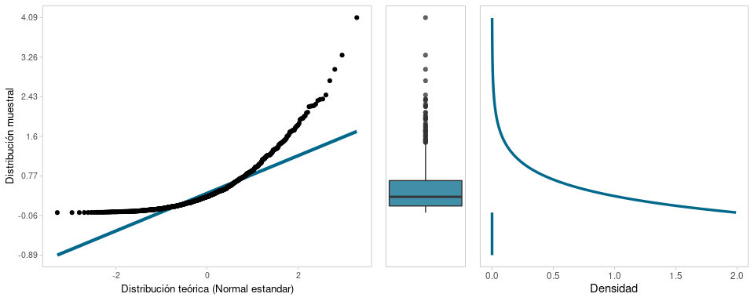

## 2.10 Distribución Gamma.

Se simula una Distribución Gamma con parámetro de forma igual a 5 y parámetro de escala igual a 3, $Gamma(\alpha=5, \lambda=3)$.

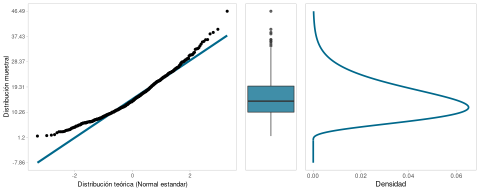

## 2.11 Distribución Beta.

Se simula una Distribución Beta con parámetro de forma igual a 6 y 2, $Beta(a=6, b=2)$.

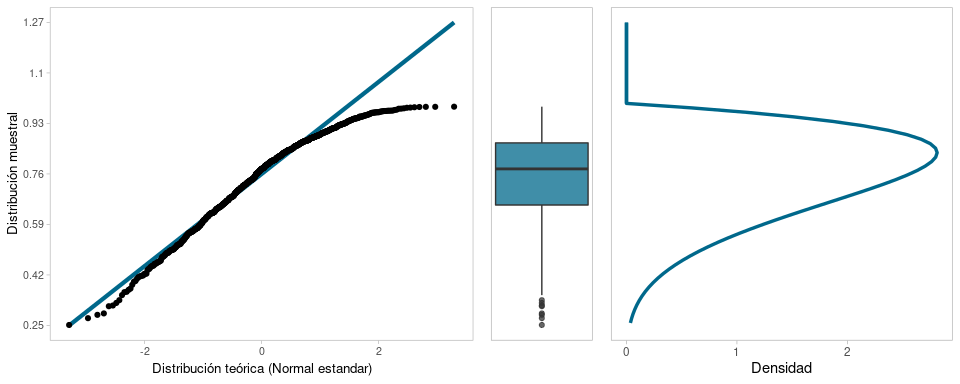

## 2.12 Distribución de Weibull.

Se simula una Distribución Weibull con parámetro de forma igual a 2 y parámetro de escala igual a 1, $Weibull(\alpha=2, \lambda=1)$.

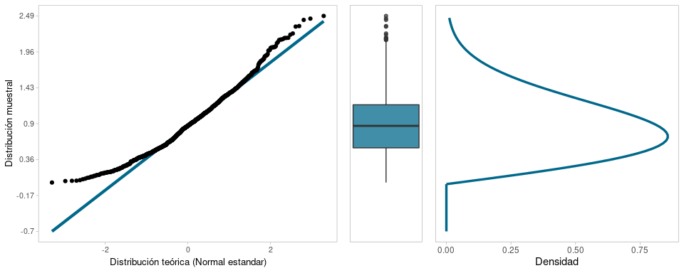

## 2.13 Distribución Normal.

Se simula una Distribución Normal con media 5 y varianza $0{,}64$, $N(\mu=5, \sigma^2=.64)$.

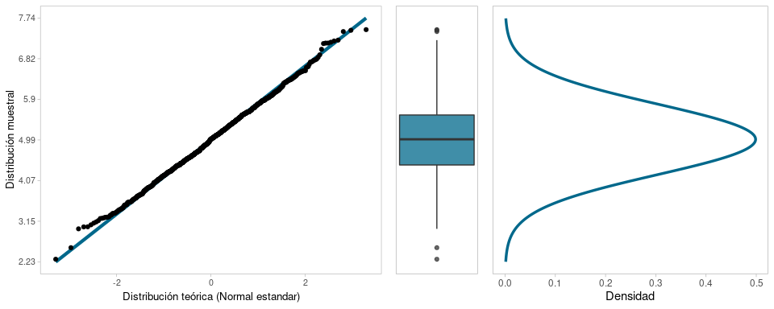

## 2.14 Distribución Chi-Cuadrado.

Se simula una Distribución Chi-Cuadrado con 3 grados de libertad, $\chi^2(\gamma=3)$.

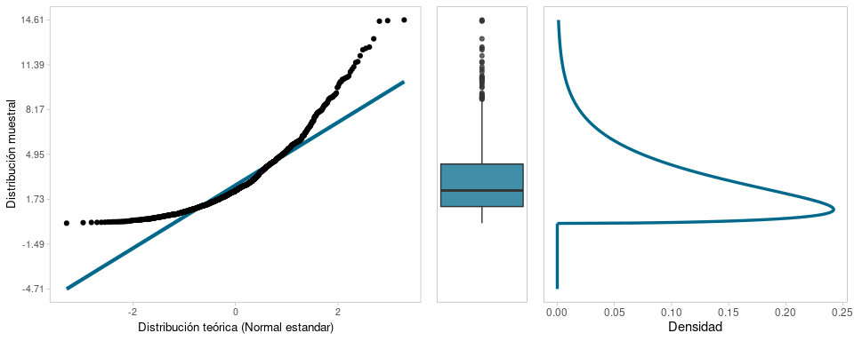

## 2.15 Distribución $t$-Student.

Se simula una Distribución $t$-Student con 4 grados de libertad, $t(\gamma=4)$.

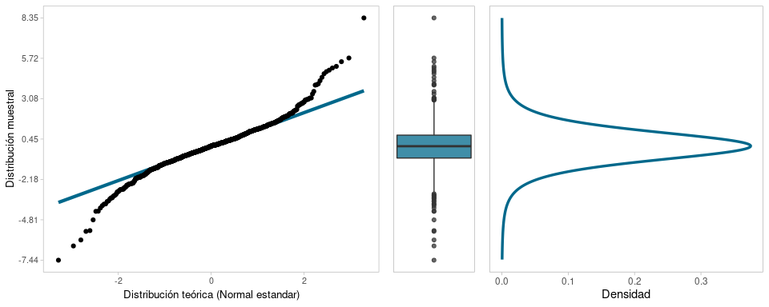

## 2.16 Distribución $F$.

Se simula una Distribución $F$ con 4 y 10 grados de libertad, $F(\gamma_1=4, \gamma_2=10)$.

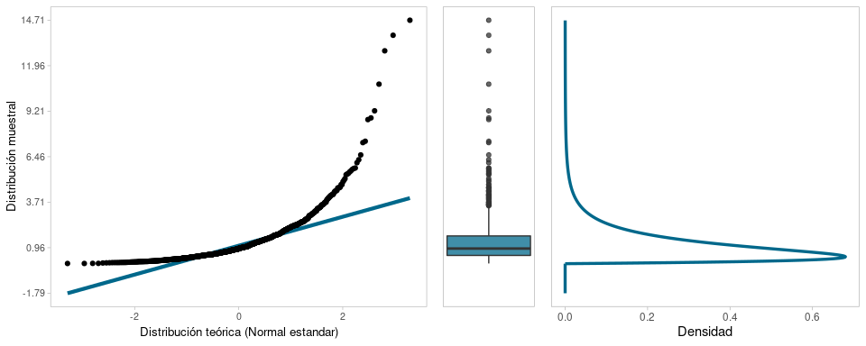

31. También calculen los coeficientes de Asimetría y kurtosis para todas las muestras de las distribuciones y explique.

Los coeficientes de asimetría y kurtosis para cada una de las distribuciones se muestran en la siguiente tabla:

| Distribución | Kurtosis | Sesgo o Asimetría |
| --- | --- | --- |
| Uniforme Discreta | 1.813 | 0.066 |
| Bernoulli | 1.753 | -0.868 |
| Binomial | 2.865 | -0.251 |
| Geometrica | 8.958 | 2.087 |
| Binomial Negativa | 4.136 | 0.961 |
| Hipergeometrica | 2.690 | 0.048 |
| Poisson | 3.093 | 0.483 |
| Uniforme Continua | 1.725 | 0.013 |
| Exponencial | 9.255 | 2.047 |
| Gamma | 3.548 | 0.714 |
| Beta | 2.959 | -0.650 |
| Weibull | 3.189 | 0.596 |
| Normal | 2.954 | 0.058 |
| Chi-Cuadrado | 5.692 | 1.493 |
| t-Student | 7.189 | 0.024 |
| F | 27.353 | 3.835 |

Los mayores valores de asimetría se obtuvieron para la distribución $F$, seguido de la exponencial y geométrica (aproximadamente 2), y la Chi-Cuadrado (aproximadamente $1{,}5$). Estas son las que muestran el mayor sesgo, con las observaciones acumulándose a la izquierda, por debajo de la media. Al igual que antes, la kurtosis es variable al igual que antes, pero en todos los casos es mucho mayor a 3, indicando que todas estas distribuciones tienen un pico agudo.

Finalmente, las únicas distribuciones que muestran sesgo negativo son la beta, la binomial y la de Bernoulli, las primeras dos con kurtosis cercana a 3, y la de Bernoulli con una kurtosis mas cercana a una platikurtica.